# NYCFlights: Arrival Delay Logictic Model

Ryan Guzalowski

5/2/17

## Logsitic and Inverse Logistic Transformation

- Write an R function for the logistic function. The function should accept a `numeric` vector with values `[-Inf,Inf]` and produce a numeric vector in the the range `[0,1]`.
- Plot the logistic function from `[-10,10]`
- Write a R function for the inverse logistic function. The function should accept a `numeric` vector with values `[0,1]` and prodcuce a numeric vector in the range `[-Inf,Inf]`
- Plot the Inverse Logistic function from `[0,1]`

**Hint:** For plotting curves see `?graphics::curve` or `?ggplot2::stat_function`

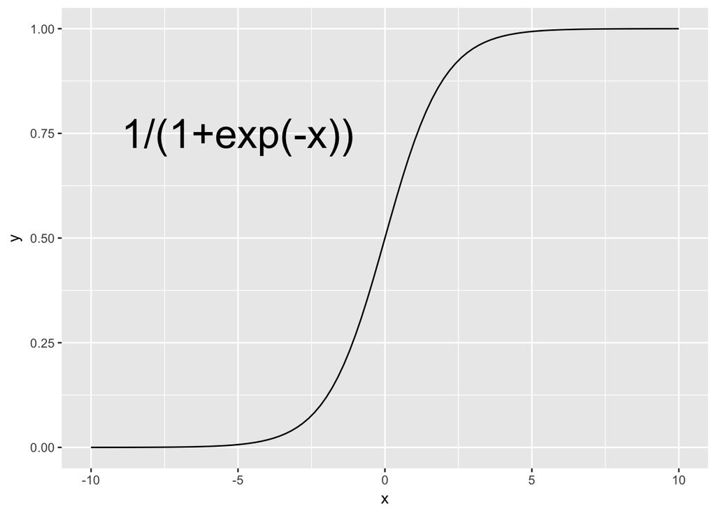

```r
lf <- function(x) {
  return (1/(1+exp(-x)))
}

p1 <- ggplot(data = data.frame(x = 0), mapping = aes(x = x))
p1 + stat_function(fun = lf) + xlim(-10,10) + annotate("text", x = -5, y = .75, label = "1/(1+exp(-x))", size = 10)
```

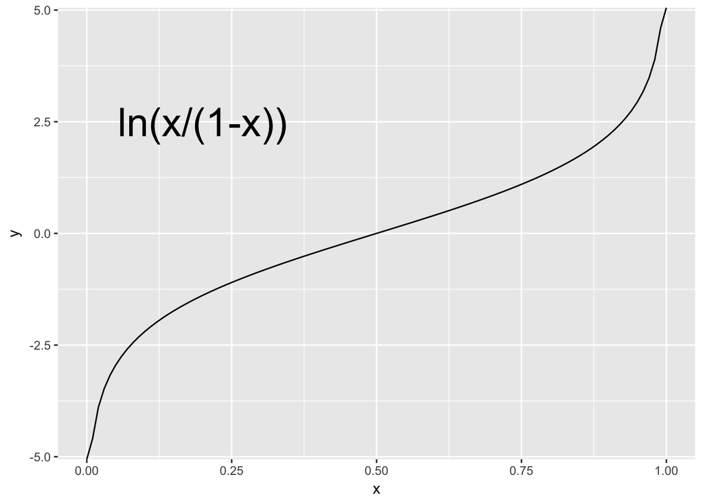

```r
lfinv <- function(y) {
  return (-log((1-y)/y))
}

p2 <- ggplot(data = data.frame(x = 0), mapping = aes(x = x))
p2 + stat_function(fun = lfinv) + xlim(0,1) + annotate("text", x = .2, y = 2.5, label = "ln(x/(1-x))", size = 10)
```

```r
# Testing that they are invereses. Input == output
test <- c(.1, .2, .4, .7, .9)
test %>% lf() %>% lfinv() %>% print()
```

```
## [1] 0.1 0.2 0.4 0.7 0.9
```

# PART A:

Using the rectangular data that you created from the earlier assignment and following the example from the text and class, create a model for arr_delay >= 22 minutes. Describe/Explain each of the steps and show all work.

KNIT YOUR DOCUMENT AS *HTML* AND SUBMIT IT AND THE `Rmd` file to your repository.

```r
# reducing sample size, choosing predictors
yx <- YX %>% sample_n(10000)
y <- "arr_delay"
xs <- c('month', 'dep_delay', 'carrier', 'air_time'
        ,'distance', 'year.pl', 'type', 'engine'
        ,'wind_dir', 'wind_speed', 'wind_gust', 'precip'
        ,'pressure', 'visib', 'lat', 'lon'
        ,'lat.dest', 'lon.dest')
yx <- yx[, c(y,xs), with = FALSE]

# setting up arrival delay to be factor of 0 (<22min) or 1 (>=22 min)
# r uses second factor to try and fit, so we make (>=22 min) == 1
yx$arr_delay[yx$arr_delay < 22] <- 0
yx$arr_delay[yx$arr_delay >= 22] <- 1
yx$arr_delay <- factor(yx$arr_delay)
levels(yx$arr_delay)
```

```
## [1] "0" "1"
```

```r
# training simple model
fit1 <- glm(arr_delay ~ dep_delay, family=binomial, data=yx)
summary(fit1)
```

```
##
## Call:
## glm(formula = arr_delay ~ dep_delay, family = binomial, data = yx)
##
## Deviance Residuals:
##     Min       1Q   Median       3Q      Max
## -2.7470  -0.3399  -0.2782  -0.2160   2.8888
##
## Coefficients:
##              Estimate Std. Error z value Pr(>|z|)
## (Intercept) -2.822116   0.050464  -55.92   <2e-16 ***
## dep_delay    0.102683   0.002464   41.68   <2e-16 ***
## ---
## Signif. codes:  0 '***' 0.001 '**' 0.01 '*' 0.05 '.' 0.1 ' ' 1
##
## (Dispersion parameter for binomial family taken to be 1)
##
##     Null deviance: 9674.0  on 9717  degrees of freedom
## Residual deviance: 4479.2  on 9716  degrees of freedom
##   (282 observations deleted due to missingness)
## AIC: 4483.2
##
## Number of Fisher Scoring iterations: 7
```

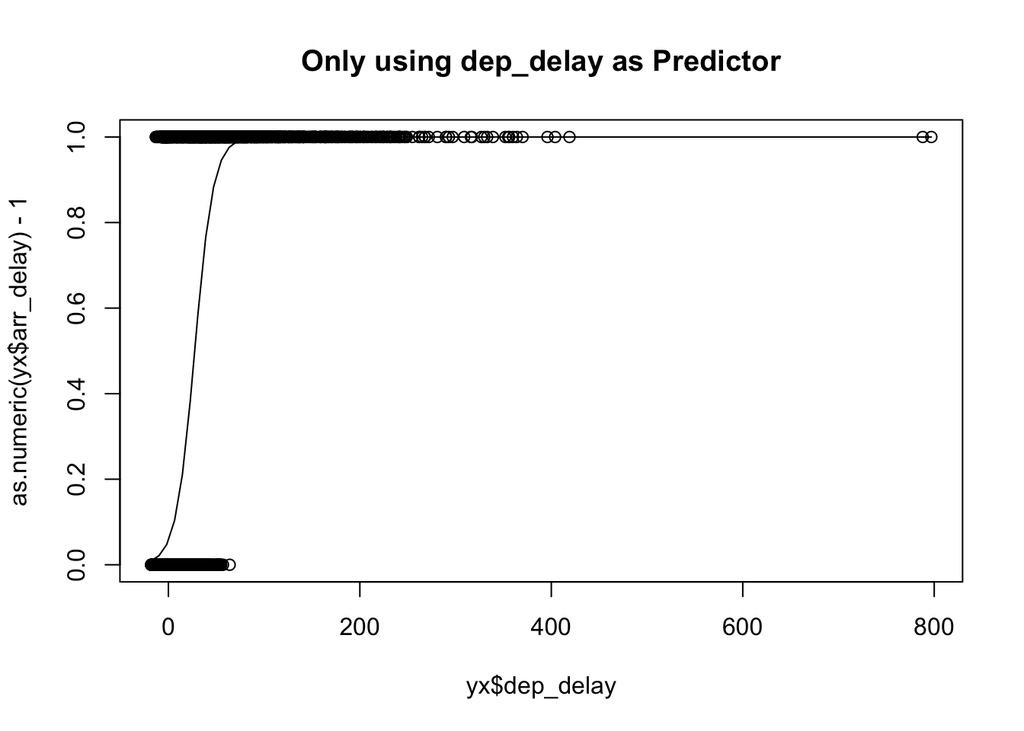

```r
plot(yx$dep_delay, as.numeric(yx$arr_delay)-1,
     main = "Only using dep_delay as Predictor")
curve(predict(fit1,data.frame(dep_delay=x),type="resp"),add=TRUE)
```

```r
# training model with all predictors included
fit2 <- glm(arr_delay ~ ., family=binomial, data=yx)
summary(fit2)
```

```
##
## Call:
## glm(formula = arr_delay ~ ., family = binomial, data = yx)
##
## Deviance Residuals:
##     Min       1Q   Median       3Q      Max
## -2.5149  -0.2833  -0.1657  -0.0830   3.6168
##
## Coefficients: (1 not defined because of singularities)
##                                Estimate Std. Error z value Pr(>|z|)
## (Intercept)                  -4.179e+01  6.046e+02  -0.069 0.944898
## month                         3.484e-03  1.463e-02   0.238 0.811746
## dep_delay                     1.283e-01  3.884e-03  33.039  < 2e-16 ***
## carrierAA                    -1.330e-01  4.559e-01  -0.292 0.770500
## carrierAS                    -8.246e+00  1.185e+01  -0.696 0.486401
## carrierB6                     2.250e-01  2.691e-01   0.836 0.403049
## carrierDL                    -6.168e-01  3.138e-01  -1.966 0.049338 *
## carrierEV                    -4.559e-02  2.926e-01  -0.156 0.876194
## carrierF9                    -1.162e+01  8.688e+01  -0.134 0.893600
## carrierFL                     9.894e-01  5.131e-01   1.928 0.053811 .
## carrierHA                    -7.907e+00  2.566e+02  -0.031 0.975420
## carrierMQ                     1.205e+00  8.692e-01   1.386 0.165739
## carrierUA                    -3.718e-01  3.245e-01  -1.146 0.251914
## carrierUS                     2.324e-01  3.253e-01   0.714 0.475085
## carrierVX                     3.349e-02  4.650e-01   0.072 0.942586
## carrierWN                    -1.061e+00  3.847e-01  -2.759 0.005799 **
## carrierYV                     1.580e+00  1.028e+00   1.537 0.124262
## air_time                      9.263e-02  4.580e-03  20.227  < 2e-16 ***
## distance                     -1.123e-02  7.976e-04 -14.075  < 2e-16 ***
## year.pl                      -2.179e-02  1.346e-02  -1.619 0.105383
## typeFixed wing single engine -2.605e+00  1.564e+00  -1.665 0.095883 .
## typeRotorcraft                1.135e+01  6.005e+02   0.019 0.984919
## engineReciprocating           1.133e+01  6.005e+02   0.019 0.984952
## engineTurbo-fan               9.961e+00  6.005e+02   0.017 0.986767
## engineTurbo-jet               1.009e+01  6.005e+02   0.017 0.986601
## engineTurbo-prop             -7.968e-01  1.068e+03  -0.001 0.999405
## engineTurbo-shaft                    NA         NA      NA       NA
## wind_dir                     -1.746e-03  5.299e-04  -3.294 0.000988 ***
## wind_speed                    8.501e+02  1.569e+03   0.542 0.588003
## wind_gust                    -7.388e+02  1.364e+03  -0.542 0.588003
## precip                        2.953e+00  2.763e+00   1.069 0.285190
## pressure                     -1.909e-02  7.320e-03  -2.608 0.009109 **
## visib                        -6.014e-02  3.241e-02  -1.855 0.063542 .
## lat                           1.583e+00  1.303e+00   1.215 0.224431
## lon                          -3.966e-01  4.434e-01  -0.894 0.371071
## lat.dest                      2.345e-03  1.969e-02   0.119 0.905199
## lon.dest                      4.167e-02  2.651e-02   1.572 0.116063
## ---
## Signif. codes:  0 '***' 0.001 '**' 0.01 '*' 0.05 '.' 0.1 ' ' 1
##
## (Dispersion parameter for binomial family taken to be 1)
##
##     Null deviance: 6701  on 7005  degrees of freedom
## Residual deviance: 2469  on 6970  degrees of freedom
##   (2994 observations deleted due to missingness)
## AIC: 2541
##
## Number of Fisher Scoring iterations: 13
```

# Question A:

Is this a good model?

# PART B:

Your model should be good at explaining tardiness. Now, assume that your job is to predict arrival delays a month in advance. You can no longer use all the features in your model. Retrain your model using only features that will be *known* only a month in advance of the departure time. Show all steps as above.

```r
# make the training set. choosing predictors that we would know only in advance
yx <- YX %>% sample_n(10000)
y <- "arr_delay"
xs <- c("origin", "month", "day", "hour", "sched_dep_time", "sched_arr_time",
        "carrier", "air_time", "distance", "type", "engines", "seats",
        "lat.dest", "lon.dest", "alt.dest")
yxb <- yx[, c(y,xs), with = FALSE]

# Set up arrival delay specifications
yxb$arr_delay[yxb$arr_delay < 22] <- 0
yxb$arr_delay[yxb$arr_delay >= 22] <- 1
yxb$arr_delay <- factor(yxb$arr_delay)
levels(yxb$arr_delay)
```

```
## [1] "0" "1"
```

```r
# training simple model
fitb1 <- glm(arr_delay ~ air_time, data = yxb, family = "binomial")
summary(fitb1)
```

```
##
## Call:
## glm(formula = arr_delay ~ air_time, family = "binomial", data = yxb)
##
## Deviance Residuals:
##     Min       1Q   Median       3Q      Max
## -0.6733  -0.6697  -0.6672  -0.6587   1.8308
##
## Coefficients:
##               Estimate Std. Error z value Pr(>|z|)
## (Intercept) -1.3655348  0.0483768 -28.227   <2e-16 ***
## air_time    -0.0001559  0.0002729  -0.571    0.568
## ---
## Signif. codes:  0 '***' 0.001 '**' 0.01 '*' 0.05 '.' 0.1 ' ' 1
##
## (Dispersion parameter for binomial family taken to be 1)
##
##     Null deviance: 9707.6  on 9711  degrees of freedom
## Residual deviance: 9707.3  on 9710  degrees of freedom
##   (288 observations deleted due to missingness)
## AIC: 9711.3
##
## Number of Fisher Scoring iterations: 4
```

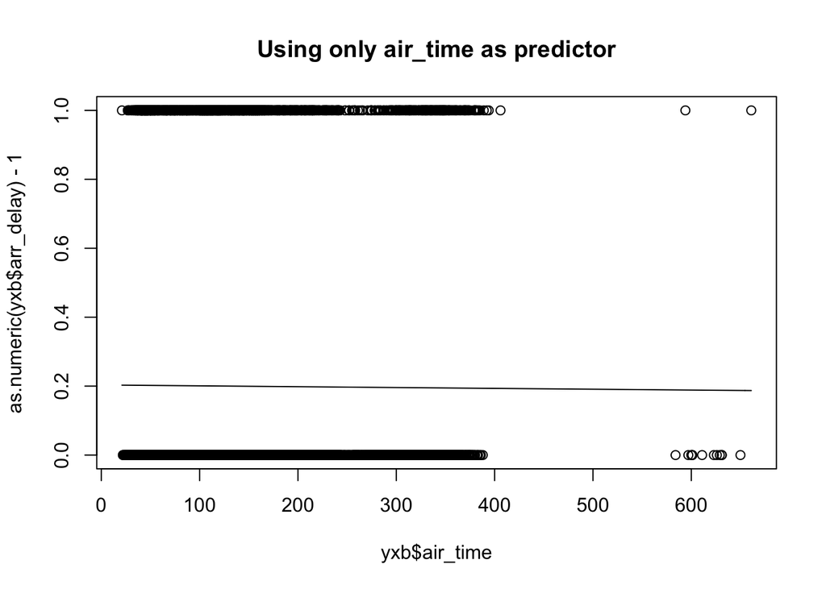

```r
plot(yxb$air_time, as.numeric(yxb$arr_delay)-1,
     main = "Using only air_time as predictor")
curve(predict(fitb1, data.frame(air_time=x),type="resp"),add=TRUE)
```

```r
# training model with all predictors
fitb2 <- glm(arr_delay ~ ., data = yxb, family = "binomial")
summary(fitb2)
```

```
##
## Call:
## glm(formula = arr_delay ~ ., family = "binomial", data = yxb)
##
## Deviance Residuals:
##     Min       1Q   Median       3Q      Max
## -1.5945  -0.7025  -0.5279  -0.3394   2.7188
##
## Coefficients:
##                                Estimate Std. Error z value Pr(>|z|)
## (Intercept)                  -4.686e+00  1.207e+00  -3.881 0.000104 ***
## originJFK                    -3.450e-02  1.025e-01  -0.337 0.736384
## originLGA                     1.505e-02  9.003e-02   0.167 0.867219
## month                        -4.773e-03  8.217e-03  -0.581 0.561336
## day                           8.610e-04  3.325e-03   0.259 0.795656
## hour                          7.278e-02  1.539e-01   0.473 0.636289
## sched_dep_time                4.663e-04  1.537e-03   0.303 0.761532
## sched_arr_time                7.174e-07  8.707e-05   0.008 0.993426
## carrierAA                    -2.072e-01  2.238e-01  -0.926 0.354402
## carrierAS                    -5.212e-01  6.861e-01  -0.760 0.447437
## carrierB6                     3.136e-01  1.470e-01   2.133 0.032894 *
## carrierDL                    -2.947e-01  1.615e-01  -1.824 0.068104 .
## carrierEV                     5.543e-01  1.533e-01   3.616 0.000299 ***
## carrierF9                     1.221e-01  6.295e-01   0.194 0.846209
## carrierFL                     7.554e-01  2.953e-01   2.558 0.010525 *
## carrierHA                    -1.064e+01  1.936e+02  -0.055 0.956188
## carrierMQ                     3.293e-01  5.823e-01   0.565 0.571776
## carrierUA                    -1.039e-02  1.703e-01  -0.061 0.951359
## carrierUS                    -2.947e-01  1.895e-01  -1.555 0.119934
## carrierVX                    -1.762e-01  2.754e-01  -0.640 0.522431
## carrierWN                     2.186e-01  2.030e-01   1.077 0.281646
## carrierYV                     7.736e-01  6.322e-01   1.224 0.221137
## air_time                      3.581e-02  2.359e-03  15.180  < 2e-16 ***
## distance                     -4.471e-03  4.059e-04 -11.016  < 2e-16 ***
## typeFixed wing single engine  3.511e-01  7.521e-01   0.467 0.640663
## typeRotorcraft               -3.040e-01  1.144e+00  -0.266 0.790376
## engines                       6.462e-01  4.667e-01   1.385 0.166178
## seats                         8.578e-04  6.390e-04   1.342 0.179454
## lat.dest                     -1.570e-03  9.910e-03  -0.158 0.874087
## lon.dest                      6.592e-03  1.365e-02   0.483 0.629047
## alt.dest                      2.950e-06  3.478e-05   0.085 0.932398
## ---
## Signif. codes:  0 '***' 0.001 '**' 0.01 '*' 0.05 '.' 0.1 ' ' 1
##
## (Dispersion parameter for binomial family taken to be 1)
##
##     Null deviance: 8116.8  on 8085  degrees of freedom
## Residual deviance: 7433.0  on 8055  degrees of freedom
##   (1914 observations deleted due to missingness)
## AIC: 7495
##
## Number of Fisher Scoring iterations: 12
```

# Question B:

Is this a good model?